# Measuring Risk in NYC

Andy Areitio, Claudia Kampbel, Pedro B Franco (INSEAD MBA Class of July 2017); Jorge Bravo

January 31, 2017

# Project Objective:

We intend to analyze and identify patterns regarding car accidents in New York City (“NYC”). In order to acheive this objective we have obtained from the New York Police Department (“NYPD”) open source data about accidents since January 7th, 2012. The table has 29 columns containing details on each accident reported to the NYPD.

Disclaimer: Please note that in order to run this project on a local computer, you will have do download a CSV file from the NYPD web site and name it as follows:

..Data/NYPD_Motor_Vehicle_Collisions.csv

Link for download: https://data.cityofnewyork.us/Public-Safety/NYPD-Motor-Vehicle-Collisions/h9gi-nx95

Thank you!

```r
# basic preparatory commands

# clear the working environment
rm(list = ls())

# load the dataset for the project
NYPDfile <- read.csv("Data/NYPD_Motor_Vehicle_Collisions.csv", header = TRUE, stringsAsFactors = FALSE)


#####

# load required packages
# install required packages if loading failed
# all packages sould be listed inside install_load()
if (!require("ggplot2")) {
  install.packages("ggplot2", repos="http://cran.rstudio.com/")
  library("ggplot2")
}
if (!require("qcc")) {
  install.packages("qcc", repos="http://cran.rstudio.com/")
  library("qcc")
}

###
```

## Project process and document structure

Please find below the process we have used to solve the proposed business problem:

**1. Defining business problem.**

As described above, our intentions are to analyze and identify patterns concerning car accidents in the city of New York. We intend to draw some conclusions from the data and generate some visualizations of the data.

**2. Find data.**

Find a good and reliable source of data. We are using official data from the Police Department of the City of New York. This data is publicly available and trustworthy. However, as we will see in the course of the analysis, there are some challenges with the data quality (e.g., non-numeric columns, missing information). We believe however, that the data gives us a good first understanding of the situation. For this project, we will therefore focus on analyzing what is available. A good next step after the project could be exploring ways to complement the data, e.g., by converting the non-numeric columns into numeric data and by extrapolating data from other sources to fill data gaps.

**3. Understand the data.**

It is important to understand the data we have at hand before trying to manipulate it. We will describe the columns on the tables as a part of this process. Depending on our findings we may have to prepare the data set for modeling:

- Check for missing values, exclusion of corresponding observations.
- Check for outliers, decision on their participation in analysis.
- Conversion of non-numerical attributes to numerical dummy variables.

Part of understanding the data will involve the following

1. Analyze data quantitatively (how many zip.codes we have, for example)
2. Number of people who die/are injured in accidents

Visualizing the data will also be part of this stage, where will try to check if we can see any of the following trends:

1. Boroughs (or ZIP codes) with most accidents
2. Boroughs (or ZIP codes) with most deaths
3. Boroughs (or ZIP codes) with most injuries
4. Histograms with the most frequent type of accident (type = # injuries or deaths)
5. Histograms with accidents per borough

**4. Define business criteria.**

We will have to define the following:

- Method for rating the accidents (i.e., rows). For this, we defined *URS* - an Universal Rating System (for accidents)
- Criteria for dangerous zip codes (scaling URS)

**5. Prepare and model solution.**

- Choose the columns/criteria that are most relevant for the analysis (dimensionality reduction)
- Develop logic/workflow
- Develop code

**6. Summarize findings and define next steps.** Test the solution and conclude the project. Conclude the project and add comments on how to improve the solution.

# 1. Business Understanding

We will focus on analyzing the risk from traffic accidents in NY city by boroughs and ZIP codes (lateron, an analysis by streets could be added). We plan to deploy our analysis and conclusions. These provide a base that could be used in the future by insurance companies, people looking for locations to buy houses in NYC, tourists looking for safest routes for walks, or even for waze-type platforms that could define their routes based on safety.

# 2. /3. Data Understanding

## Source of data

We have downloaded open source data from the following site: (https://data.cityofnewyork.us/Public-Safety/NYPD-Motor-Vehicle-Collisions/h9gi-nx95).

## Dataset size and variables

Each line of the table represents an incident involving a motor car vehicle in NYC since January 7th 2012.

Please find below a brief description of the columns:

1. DATE (Floating Time Stamp) - Date of the incident
2. TIME (Text) - Time the incident occured
3. BOROUGH (Text) - The Bourough the accident occured
4. ZIP.CODE (Text) - The Zipcode of the location
5. LATITUDE (Number #) - Latitude of the location the accident occured
6. LONGITUDE (Number #) - Longitude of the location the accident occured
7. LOCATION (Location Datatype) - Location, where logitude and latitude are joined and can be refferenced to a map
8. ON.STREET.NAME (Plain text) - Name of the street the accident occured
9. CROSS.STREET.NAME (Plain text) - Closest cross street
10. OFF.STREET.NAME (Plain text)
11. NUMBER.OF.PERSONS.INJURED (Number #)
12. NUMBER.OF.PERSONS.KILLED (Number #)
13. NUMBER.OF.PEDESTRIANS.INJURED (Number #)
14. NUMBER.OF.PEDESTRIANS.KILLED (Number #)
15. NUMBER.OF.CYCLIST.INJURED (Number #)
16. NUMBER.OF.CYCLIST.KILLED (Number #)
17. NUMBER.OF.MOTORIST.INJURED (Number #)
18. NUMBER.OF.MOTORIST.KILLED (Number #)
19. CONTRIBUTING.FACTOR.VEHICLE.1 (Plain text) - Main factor which caused the accident (Driver Inexperience, Driver Inattention, Turning Improperly, etc…)
20. CONTRIBUTING.FACTOR.VEHICLE.2 (Plain text)
21. CONTRIBUTING.FACTOR.VEHICLE.3 (Plain text)
22. CONTRIBUTING.FACTOR.VEHICLE.4 (Plain text)
23. CONTRIBUTING.FACTOR.VEHICLE.5 (Plain text)
24. UNIQUE.KEY (Number #)
25. VEHICLE.TYPE.CODE.1 (Plain text) - Type of Vehicle 1 (sports utility, taxi, passenger, bus, etc)
26. VEHICLE.TYPE.CODE.2 (Plain text)
27. VEHICLE.TYPE.CODE.3 (Plain text)
28. VEHICLE.TYPE.CODE.4 (Plain text)
29. VEHICLE.TYPE.CODE.5 (Plain text)

First, let’s generate a summary report for all variables.

Below is the summary of the project dataset structure.

```r
#colnames(NYPDfile)
nrow(NYPDfile)
```

```
## [1] 966889
```

```r
ncol(NYPDfile)
```

```
## [1] 29
```

```r
summary(NYPDfile)
```

```
##      DATE               TIME             BOROUGH             ZIP.CODE
##  Length:966889      Length:966889      Length:966889      Min.   :10000
##  Class :character   Class :character   Class :character   1st Qu.:10075
##  Mode  :character   Mode  :character   Mode  :character   Median :11204
##                                                           Mean   :10808
##                                                           3rd Qu.:11236
##                                                           Max.   :11697
##                                                           NA's   :252229
##     LATITUDE        LONGITUDE        LOCATION         ON.STREET.NAME
##  Min.   :40.50    Min.   :-74.25   Length:966889      Length:966889
##  1st Qu.:40.67    1st Qu.:-73.98   Class :character   Class :character
##  Median :40.72    Median :-73.93   Mode  :character   Mode  :character
##  Mean   :40.72    Mean   :-73.92
##  3rd Qu.:40.77    3rd Qu.:-73.87
##  Max.   :40.91    Max.   :-73.70
##  NA's   :201194   NA's   :201194
##  CROSS.STREET.NAME  OFF.STREET.NAME    NUMBER.OF.PERSONS.INJURED
##  Length:966889      Length:966889      Min.   : 0.0000
##  Class :character   Class :character   1st Qu.: 0.0000
##  Mode  :character   Mode  :character   Median : 0.0000
##                                        Mean   : 0.2554
##                                        3rd Qu.: 0.0000
##                                        Max.   :43.0000
##
##  NUMBER.OF.PERSONS.KILLED NUMBER.OF.PEDESTRIANS.INJURED
##  Min.   :0.000000         Min.   : 0.00000
##  1st Qu.:0.000000         1st Qu.: 0.00000
##  Median :0.000000         Median : 0.00000
##  Mean   :0.001226         Mean   : 0.05398
##  3rd Qu.:0.000000         3rd Qu.: 0.00000
##  Max.   :5.000000         Max.   :15.00000
##
##  NUMBER.OF.PEDESTRIANS.KILLED NUMBER.OF.CYCLIST.INJURED
##  Min.   :0.0000000            Min.   :0.00000
##  1st Qu.:0.0000000            1st Qu.:0.00000
##  Median :0.0000000            Median :0.00000
##  Mean   :0.0007157            Mean   :0.02108
##  3rd Qu.:0.0000000            3rd Qu.:0.00000
##  Max.   :3.0000000            Max.   :6.00000
##
```

[output cut: 33 more lines]

```
##  Min.   :     22   Length:966889       Length:966889
##  1st Qu.: 243512   Class :character    Class :character
##  Median :3097332   Mode  :character    Mode  :character
##  Mean   :2015464
##  3rd Qu.:3361287
##  Max.   :3604016
##
##  VEHICLE.TYPE.CODE.3 VEHICLE.TYPE.CODE.4 VEHICLE.TYPE.CODE.5
##  Length:966889       Length:966889       Length:966889
##  Class :character    Class :character    Class :character
##  Mode  :character    Mode  :character    Mode  :character
##
##
##
##
```

Note: ‘Date’ and ‘Time’ columns are defined as characters and not numerical. These variables are not key to our primary analysis (assessing the risk of having an accident in a specified ZIP code/borough) so we will focus on the remaining variables.

```r
#analyzing categorical variables and unique values
sapply(NYPDfile, function(x) length(unique(x)))
```

```
##                          DATE                          TIME
##                          1667                          1440
##                       BOROUGH                      ZIP.CODE
##                             6                           211
##                      LATITUDE                     LONGITUDE
##                         71658                         71784
##                      LOCATION                ON.STREET.NAME
##                         72678                          9063
##             CROSS.STREET.NAME               OFF.STREET.NAME
##                          9485                         55665
##     NUMBER.OF.PERSONS.INJURED      NUMBER.OF.PERSONS.KILLED
##                            24                             6
## NUMBER.OF.PEDESTRIANS.INJURED  NUMBER.OF.PEDESTRIANS.KILLED
##                            12                             4
##     NUMBER.OF.CYCLIST.INJURED      NUMBER.OF.CYCLIST.KILLED
##                             7                             3
##    NUMBER.OF.MOTORIST.INJURED     NUMBER.OF.MOTORIST.KILLED
##                            29                             6
## CONTRIBUTING.FACTOR.VEHICLE.1 CONTRIBUTING.FACTOR.VEHICLE.2
##                            49                            49
## CONTRIBUTING.FACTOR.VEHICLE.3 CONTRIBUTING.FACTOR.VEHICLE.4
##                            43                            42
## CONTRIBUTING.FACTOR.VEHICLE.5                    UNIQUE.KEY
##                            29                        966889
##           VEHICLE.TYPE.CODE.1           VEHICLE.TYPE.CODE.2
##                            18                            18
##           VEHICLE.TYPE.CODE.3           VEHICLE.TYPE.CODE.4
##                            18                            18
##           VEHICLE.TYPE.CODE.5
##                            16
```

```r
#zooming in one column
 unique(NYPDfile$BOROUGH)
```

```
## [1] ""              "BRONX"         "QUEENS"        "MANHATTAN"
## [5] "BROOKLYN"      "STATEN ISLAND"
```

Also, the summary shows that there are a lot of NA’s in certain columns (e.g., borough) which could be difficult to use. We will visualize the data to find out more. In a first step, we replace the empty cells in the columns Borough (ZIP code) with “UNSPECIFIED” (00000).

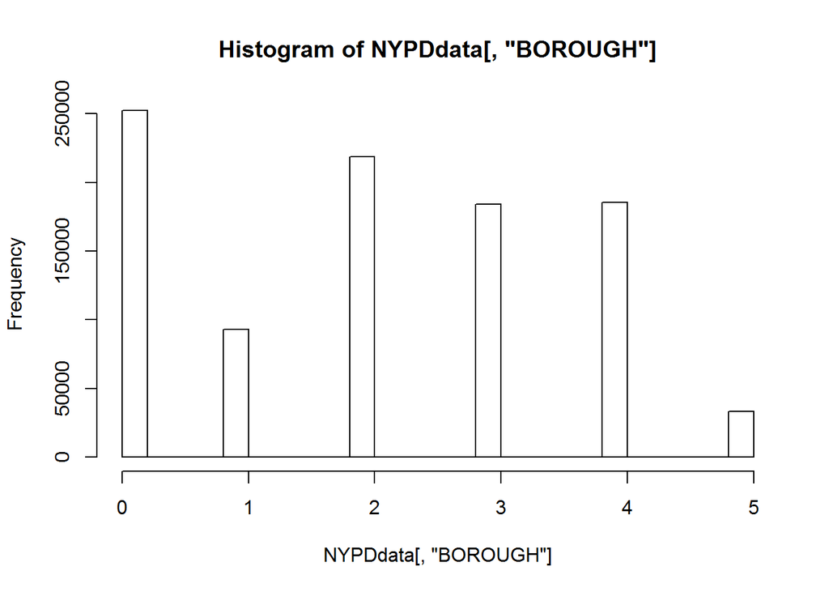

```r
NYPDfile$BOROUGH[NYPDfile$BOROUGH == ""] <- "UNSPECIFIED"
NYPDfile$ZIP.CODE[is.na(NYPDfile$ZIP.CODE)] <- "00000"


#histogram

NYPDdata <- NYPDfile$UNIQUE.KEY
NYPDdata <- cbind(NYPDdata, NYPDfile$BOROUGH)
colnames(NYPDdata) <- c("ID", "BOROUGH")

NYPDdata[,"BOROUGH"] <- replace(NYPDdata[,"BOROUGH"], NYPDdata[,"BOROUGH"]=="UNSPECIFIED", 0)
NYPDdata[,"BOROUGH"] <- replace(NYPDdata[,"BOROUGH"], NYPDdata[,"BOROUGH"]=="BRONX", 1)
NYPDdata[,"BOROUGH"] <- replace(NYPDdata[,"BOROUGH"], NYPDdata[,"BOROUGH"]=="BROOKLYN", 2)
NYPDdata[,"BOROUGH"] <- replace(NYPDdata[,"BOROUGH"], NYPDdata[,"BOROUGH"]=="MANHATTAN", 3)
NYPDdata[,"BOROUGH"] <- replace(NYPDdata[,"BOROUGH"], NYPDdata[,"BOROUGH"]=="QUEENS", 4)
NYPDdata[,"BOROUGH"] <- replace(NYPDdata[,"BOROUGH"], NYPDdata[,"BOROUGH"]=="STATEN ISLAND", 5)

NYPDdata<-matrix(as.numeric(unlist(NYPDdata)),nrow=nrow(NYPDdata))
colnames(NYPDdata) <- c("ID", "BOROUGH")

hist(NYPDdata[,"BOROUGH"])
```

With

0 = UNSPECIFIED 1 = BRONX 2 = BROOKLYN 3 = MANHATTAN 4 = QUEENS 5 = STATEN ISLAND

The histogram shows that there are a lot of emtpy cells in the BOROUGH column.

When solving this question, we realize that in the rows with unknown value for Borough value, the zip code is also unknown. The only values regarding location that are partially available for these incidents On.Street.Name, Cross.Street.Name and Off.Street.Name.

To assess how many rows are complete the next step is to count how many empty values we have in the column Borough.

```
## [1] 252133
```

```
## [1] 252133
```

For the column ZIP code, we have the following amount of empty cells:

```
## [1] 252229
```

In total, the percentage of unknown borough/ZIP code values is small enough to allow a sensible analysis:

```
## [1] 26.07673
```

Percent of the data does not include values for the columns ZIP.CODE AND BOROUGH.

## Dataset visualization

1. We will now plot a graph with accidents per borough (independent of time and date):

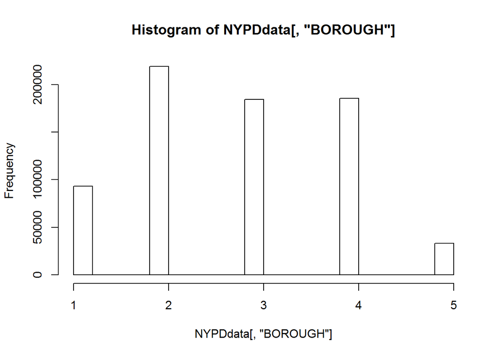

```r
NYPDdata_knownBorough <- NYPDdata[-c(0),]
#NYPDdata_knownBorough <- subset(NYPDdata,"BOROUGH"!=0)

NYPDfile$BOROUGH[NYPDfile$BOROUGH == ""] <- "UNSPECIFIED"
NYPDfile$ZIP.CODE[is.na(NYPDfile$ZIP.CODE)] <- "00000"


#histogram

NYPDdata <- NYPDfile$UNIQUE.KEY
NYPDdata <- cbind(NYPDdata, NYPDfile$BOROUGH)
colnames(NYPDdata) <- c("ID", "BOROUGH")

#NYPDdata[,"BOROUGH"] <- replace(NYPDdata[,"BOROUGH"], NYPDdata[,"BOROUGH"]=="UNSPECIFIED", 0)
NYPDdata[,"BOROUGH"] <- replace(NYPDdata[,"BOROUGH"], NYPDdata[,"BOROUGH"]=="BRONX", 1)
NYPDdata[,"BOROUGH"] <- replace(NYPDdata[,"BOROUGH"], NYPDdata[,"BOROUGH"]=="BROOKLYN", 2)
NYPDdata[,"BOROUGH"] <- replace(NYPDdata[,"BOROUGH"], NYPDdata[,"BOROUGH"]=="MANHATTAN", 3)
NYPDdata[,"BOROUGH"] <- replace(NYPDdata[,"BOROUGH"], NYPDdata[,"BOROUGH"]=="QUEENS", 4)
NYPDdata[,"BOROUGH"] <- replace(NYPDdata[,"BOROUGH"], NYPDdata[,"BOROUGH"]=="STATEN ISLAND", 5)

NYPDdata<-matrix(as.numeric(unlist(NYPDdata)),nrow=nrow(NYPDdata))
colnames(NYPDdata) <- c("ID", "BOROUGH")

hist(NYPDdata[,"BOROUGH"])
```

With

1 = BRONX 2 = BROOKLYN 3 = MANHATTAN 4 = QUEENS 5 = STATEN ISLAND

*According to our sample, the boroughs with the highest number of accidents are Brooklyn and Queens.*

2. Generate tables with accidents per borough / per type of victim (cyclist / Pedestrian / Motorist):
1. Total number of people killed by BOROUGH (Cyclists+Pededstrians+Motorists)
2. Total number of people injured by BOROUGH (Cyclists+Pededstrians+Motorists)
3. Number of cyclists killed by BOROUGH
4. Number of cyclists injured by BOROUGH
5. Number of pedestrians killed by BOROUGH
6. Number of pedestrians injured by BOROUGH
7. Number of Motorists killed by BOROUGH
8. Number of Motorists injured by BOROUGH

```r
PERSONS.K <- aggregate(NYPDfile$NUMBER.OF.PERSONS.KILLED, list(Borough = NYPDfile$BOROUGH), sum)
PERSONS.I <- aggregate(NYPDfile$NUMBER.OF.PERSONS.INJURED, list(Borough = NYPDfile$BOROUGH), sum)
CYCLISTS.K <- aggregate(NYPDfile$NUMBER.OF.CYCLIST.KILLED, list(Borough = NYPDfile$BOROUGH), sum)
CYCLISTS.I <- aggregate(NYPDfile$NUMBER.OF.CYCLIST.INJURED, list(Borough = NYPDfile$BOROUGH), sum)
PED.K <- aggregate(NYPDfile$NUMBER.OF.PEDESTRIANS.KILLED, list(Borough = NYPDfile$BOROUGH), sum)
PED.I <- aggregate(NYPDfile$NUMBER.OF.PEDESTRIANS.INJURED, list(Borough = NYPDfile$BOROUGH), sum)
MOT.K <- aggregate(NYPDfile$NUMBER.OF.MOTORIST.KILLED, list(Borough = NYPDfile$BOROUGH), sum)
MOT.I <- aggregate(NYPDfile$NUMBER.OF.MOTORIST.INJURED, list(Borough = NYPDfile$BOROUGH), sum)


PERSONS.K
```

```
##         Borough   x
## 1         BRONX 113
## 2      BROOKLYN 272
## 3     MANHATTAN 149
## 4        QUEENS 237
## 5 STATEN ISLAND  46
## 6   UNSPECIFIED 368
```

```r
PERSONS.I
```

```
##         Borough     x
## 1         BRONX 26930
## 2      BROOKLYN 64876
## 3     MANHATTAN 31316
## 4        QUEENS 48018
## 5 STATEN ISLAND  8047
## 6   UNSPECIFIED 67734
```

```r
CYCLISTS.K
```

```
##         Borough  x
## 1         BRONX  7
## 2      BROOKLYN 22
## 3     MANHATTAN 12
## 4        QUEENS 17
## 5 STATEN ISLAND  2
## 6   UNSPECIFIED 15
```

```r
CYCLISTS.I
```

```
##         Borough    x
## 1         BRONX 1607
## 2      BROOKLYN 7064
## 3     MANHATTAN 5302
## 4        QUEENS 3468
## 5 STATEN ISLAND  179
## 6   UNSPECIFIED 2758
```

```r
PED.K
```

```
##         Borough   x
## 1         BRONX  71
## 2      BROOKLYN 167
## 3     MANHATTAN 119
## 4        QUEENS 138
## 5 STATEN ISLAND  19
## 6   UNSPECIFIED 178
```

```r
PED.I
```

```
##         Borough     x
## 1         BRONX  6926
## 2      BROOKLYN 15301
## 3     MANHATTAN 11433
## 4        QUEENS 10294
## 5 STATEN ISLAND  1261
## 6   UNSPECIFIED  6982
```

```r
MOT.K
```

```
##         Borough   x
## 1         BRONX  38
## 2      BROOKLYN  93
## 3     MANHATTAN  20
## 4        QUEENS  86
## 5 STATEN ISLAND  25
## 6   UNSPECIFIED 194
```

```r
MOT.I
```

```
##         Borough     x
## 1         BRONX 19595
## 2      BROOKLYN 44639
## 3     MANHATTAN 15482
## 4        QUEENS 36437
## 5 STATEN ISLAND  6837
## 6   UNSPECIFIED 62792
```

```r
##NYPDdata<-matrix(as.numeric(unlist(NYPDdata)),nrow=nrow(NYPDdata))
##colnames(NYPDdata) <- c("ID", "BOROUGH")

##hist(NYPDdata[,"BOROUGH"])
```

From this data we can draw the following conclusions: a. Brooklyn and Queens have the largest amount of deaths and injures (in total) b. However, there are more cyclists injured in Manhattan than in Queens (maybe people cycle more in Manhattan than in Queens) c. Similarly, there are more pedestrians injured in Manhattan than in queens (maybe people like walking a lot more in Manhattan - makes sense!) d. For motorists, Brooklyn, Queens and Bronx have the largest amount of deaths and injuries (Makes sense as in Manhattan cars can’t go very fast)

3. Generate a histogram with the type of vehicle that was involved in the accident:

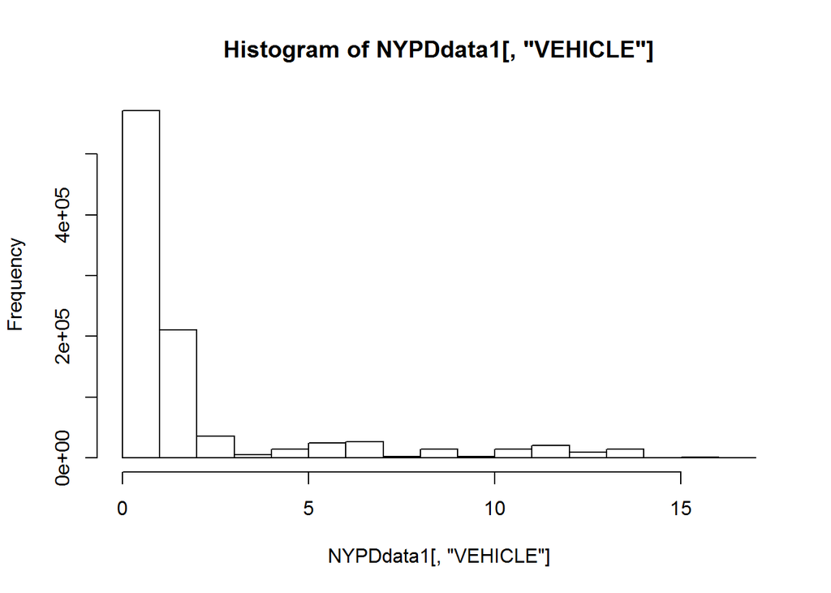

```r
NYPDfile$VEHICLE.TYPE.CODE.1[NYPDfile$VEHICLE.TYPE.CODE.1 == ""] <- "0000"

#histogram

NYPDdata1 <- NYPDfile$UNIQUE.KEY
NYPDdata1 <- cbind(NYPDdata1, NYPDfile$VEHICLE.TYPE.CODE.1)
colnames(NYPDdata1) <- c("ID", "VEHICLE")

#NYPDdata1[,"VEHICLE"] <- replace(NYPDdata1[,"VEHICLE"], NYPDdata1[,"VEHICLE"]=="0000", 0)
NYPDdata1[,"VEHICLE"] <- replace(NYPDdata1[,"VEHICLE"], NYPDdata1[,"VEHICLE"]=="PASSENGER VEHICLE", 1)
NYPDdata1[,"VEHICLE"] <- replace(NYPDdata1[,"VEHICLE"], NYPDdata1[,"VEHICLE"]=="SPORT UTILITY / STATION WAGON", 2)
NYPDdata1[,"VEHICLE"] <- replace(NYPDdata1[,"VEHICLE"], NYPDdata1[,"VEHICLE"]=="TAXI", 3)
NYPDdata1[,"VEHICLE"] <- replace(NYPDdata1[,"VEHICLE"], NYPDdata1[,"VEHICLE"]=="MOTORCYCLE", 4)
NYPDdata1[,"VEHICLE"] <- replace(NYPDdata1[,"VEHICLE"], NYPDdata1[,"VEHICLE"]=="PICK-UP TRUCK", 5)
NYPDdata1[,"VEHICLE"] <- replace(NYPDdata1[,"VEHICLE"], NYPDdata1[,"VEHICLE"]=="OTHER", 6)
NYPDdata1[,"VEHICLE"] <- replace(NYPDdata1[,"VEHICLE"], NYPDdata1[,"VEHICLE"]=="VAN", 7)
NYPDdata1[,"VEHICLE"] <- replace(NYPDdata1[,"VEHICLE"], NYPDdata1[,"VEHICLE"]=="BICYCLE", 8)
NYPDdata1[,"VEHICLE"] <- replace(NYPDdata1[,"VEHICLE"], NYPDdata1[,"VEHICLE"]=="SMALL COM VEH(4 TIRES)", 9)
NYPDdata1[,"VEHICLE"] <- replace(NYPDdata1[,"VEHICLE"], NYPDdata1[,"VEHICLE"]=="AMBULANCE", 10)
NYPDdata1[,"VEHICLE"] <- replace(NYPDdata1[,"VEHICLE"], NYPDdata1[,"VEHICLE"]=="LARGE COM VEH(6 OR MORE TIRES)", 11)
NYPDdata1[,"VEHICLE"] <- replace(NYPDdata1[,"VEHICLE"], NYPDdata1[,"VEHICLE"]=="UNKNOWN", 12)
NYPDdata1[,"VEHICLE"] <- replace(NYPDdata1[,"VEHICLE"], NYPDdata1[,"VEHICLE"]=="LIVERY VEHICLE", 13)
NYPDdata1[,"VEHICLE"] <- replace(NYPDdata1[,"VEHICLE"], NYPDdata1[,"VEHICLE"]=="BUS", 14)
NYPDdata1[,"VEHICLE"] <- replace(NYPDdata1[,"VEHICLE"], NYPDdata1[,"VEHICLE"]=="SCOOTER", 15)
NYPDdata1[,"VEHICLE"] <- replace(NYPDdata1[,"VEHICLE"], NYPDdata1[,"VEHICLE"]=="FIRE TRUCK", 16)
NYPDdata1[,"VEHICLE"] <- replace(NYPDdata1[,"VEHICLE"], NYPDdata1[,"VEHICLE"]=="PEDICAB", 17)

NYPDdata1<-matrix(as.numeric(unlist(NYPDdata1)),nrow=nrow(NYPDdata1))
colnames(NYPDdata1) <- c("ID", "VEHICLE")

hist(NYPDdata1[,"VEHICLE"])
```

Where: 1 PASSENGER VEHICLE 2 SPORT UTILITY / STATION WAGON 3 TAXI 4 MOTORCYCLE 5 PICK-UP TRUCK 6 OTHER 7 VAN 8 BICYCLE 9 SMALL COM VEH(4 TIRES) 10 AMBULANCE 11 LARGE COM VEH(6 OR MORE TIRES) 12 UNKNOWN 13 LIVERY VEHICLE 14 BUS 15 SCOOTER 16 FIRE TRUCK 17 PEDICAB

From our new histogram, we can conclude that passanger vehicles and sport utilities are the ones involved with the highest # of accidents.

## 4. Define Business Criteria

```r
NYPDfile$URS <- NYPDfile$NUMBER.OF.PERSONS.KILLED*2000+NYPDfile$NUMBER.OF.PERSONS.INJURED*10+1
```

A. Here is a simple table of URS per borough

```r
aggregate(NYPDfile$URS, list(Borough = NYPDfile$BOROUGH), sum)
```

```
##         Borough       x
## 1         BRONX  588286
## 2      BROOKLYN 1411610
## 3     MANHATTAN  795385
## 4        QUEENS 1139633
## 5 STATEN ISLAND  205712
## 6   UNSPECIFIED 1665473
```

From this table, we can see that in our sample, Brooklyn is the most dangerous borough according to the URS scale.

We can also assess the average URS of an accident per borough:

```r
aggregate(NYPDfile$URS, list(Borough = NYPDfile$BOROUGH), mean)
```

```
##         Borough        x
## 1         BRONX 6.326608
## 2      BROOKLYN 6.450126
## 3     MANHATTAN 4.317465
## 4        QUEENS 6.145131
## 5 STATEN ISLAND 6.188316
## 6   UNSPECIFIED 6.605534
```

This is interesting: The Unspecified accidents have the highest URS index, therefore we can infer, as a hypothesis, that many of the most dangerous accidents are not properly classified. Maybe because the police men are worried with the outcome, emergencies, etc…

Brooklyn is the most dangerous borough and Bronx has the second highest URS, although it was forth in the number of accidents. This suggests that people drive faster or more agressively in the Bronx.

# 5. Prepare and model solution

For our primary analysis, we will focus on the following data

- order NY by ZIP codes analyse the following criteria
- URS
- Amount of Accidents
- Amount of injuries and deaths (Total, Pedestrians, Cyclists)

We start with simple tables (independent of time and date and ordered from largest # of accidents to smallest): *note: only Table heads are displayed to reduce the length of the report*

1. Accidents per zip code
2. Deaths per zip code
3. Injuries per zip code

```r
PERSONS.K.Z <- aggregate(NYPDfile$NUMBER.OF.PERSONS.KILLED, list(ZIP.CODE = NYPDfile$ZIP.CODE), sum)
PERSONS.I.Z <- aggregate(NYPDfile$NUMBER.OF.PERSONS.INJURED, list(ZIP.CODE = NYPDfile$ZIP.CODE), sum)
CYCLISTS.K.Z <- aggregate(NYPDfile$NUMBER.OF.CYCLIST.KILLED, list(ZIP.CODE = NYPDfile$ZIP.CODE), sum)
CYCLISTS.I.Z <- aggregate(NYPDfile$NUMBER.OF.CYCLIST.INJURED, list(ZIP.CODE = NYPDfile$ZIP.CODE), sum)
PED.K.Z <- aggregate(NYPDfile$NUMBER.OF.PEDESTRIANS.KILLED, list(ZIP.CODE = NYPDfile$ZIP.CODE), sum)
PED.I.Z <- aggregate(NYPDfile$NUMBER.OF.PEDESTRIANS.INJURED, list(ZIP.CODE = NYPDfile$ZIP.CODE), sum)
URS.Z <- aggregate(NYPDfile$URS, list(ZIP.CODE = NYPDfile$ZIP.CODE), sum)

# ordering the data to display most dangerous ZIP codes first

URS.Z_nb = c(URS.Z$ZIP.CODE,URS.Z$x)
URS.Z_nb =as.vector(t(URS.Z))
URS.Z_nb =as.vector(as.matrix(URS.Z))
URS.Z.ord <- URS.Z[order(-URS.Z[,"x"]),]

PERSONS.K.Z_nb = c(PERSONS.K.Z$ZIP.CODE,PERSONS.K.Z$x)
PERSONS.K.Z_nb =as.vector(t(PERSONS.K.Z))
PERSONS.K.Z_nb =as.vector(as.matrix(PERSONS.K.Z))
PERSONS.K.Z.ord <- PERSONS.K.Z[order(-PERSONS.K.Z[,"x"]),]

PERSONS.I.Z_nb = c(PERSONS.I.Z$ZIP.CODE,PERSONS.I.Z$x)
PERSONS.I.Z_nb =as.vector(t(PERSONS.I.Z))
PERSONS.I.Z_nb =as.vector(as.matrix(PERSONS.I.Z))
PERSONS.I.Z.ord <- PERSONS.I.Z[order(-PERSONS.I.Z[,"x"]),]

CYCLISTS.K.Z_nb = c(CYCLISTS.K.Z$ZIP.CODE,CYCLISTS.K.Z$x)
CYCLISTS.K.Z_nb =as.vector(t(CYCLISTS.K.Z))
CYCLISTS.K.Z_nb =as.vector(as.matrix(CYCLISTS.K.Z))
CYCLISTS.K.Z.ord <- CYCLISTS.K.Z[order(-CYCLISTS.K.Z[,"x"]),]

CYCLISTS.I.Z_nb = c(CYCLISTS.I.Z$ZIP.CODE,CYCLISTS.I.Z$x)
CYCLISTS.I.Z_nb =as.vector(t(CYCLISTS.I.Z))
CYCLISTS.I.Z_nb =as.vector(as.matrix(CYCLISTS.I.Z))
CYCLISTS.I.Z.ord <- CYCLISTS.K.Z[order(-CYCLISTS.I.Z[,"x"]),]

PED.K.Z_nb = c(PED.K.Z$ZIP.CODE,PED.K.Z$x)
PED.K.Z_nb =as.vector(t(PED.K.Z))
PED.K.Z_nb =as.vector(as.matrix(PED.K.Z))
PED.K.Z.ord <- PED.K.Z[order(-PED.K.Z[,"x"]),]

PED.I.Z_nb = c(PED.I.Z$ZIP.CODE,PED.I.Z$x)
PED.I.Z_nb =as.vector(t(PED.K.Z))
PED.I.Z_nb =as.vector(as.matrix(PED.I.Z))
PED.I.Z.ord <- PED.I.Z[order(-PED.I.Z[,"x"]),]
```

These are the most dangerous ZIP codes by URS (ignore 00000 as this is not actual ZIP):

```r
head(URS.Z.ord)
```

```
##     ZIP.CODE       x
## 1      00000 1665869
## 123    11207   90482
## 151    11236   82011
## 119    11203   67730
## 203    11434   63807
## 124    11208   58156
```

These are the most dangerous ZIP codes by total deaths in traffic accidents (ignore 00000 as this is not actual ZIP):

```r
head(PERSONS.K.Z.ord)
```

```
##     ZIP.CODE   x
## 1      00000 368
## 151    11236  22
## 203    11434  16
## 123    11207  15
## 25     10025  13
## 144    11229  13
```

We can see that 11236 ZIP.CODE (Canarsie) has the highest number of accidents which result in death. Its positioned in the outskirts of NYC in Brooklyn.

These are the most dangerous ZIP codes by total injuries in traffic accidents (ignore 00000 as this is not actual ZIP):

```r
head(PERSONS.I.Z.ord)
```

```
##     ZIP.CODE     x
## 1      00000 67764
## 123    11207  4783
## 119    11203  3507
## 151    11236  2990
## 142    11226  2807
## 128    11212  2775
```

These are the most dangerous ZIP codes by cyclist deaths or injuries in traffic accidents (ignore 00000 as this is not actual ZIP):

```r
head(CYCLISTS.K.Z.ord)
```

```
##     ZIP.CODE  x
## 1      00000 15
## 29     10029  4
## 35     10035  2
## 111    11101  2
## 123    11207  2
## 133    11217  2
```

```r
head(CYCLISTS.I.Z.ord)
```

[output not shown]

```r
head(PED.K.Z.ord)
```

```
##     ZIP.CODE   x
## 1      00000 178
## 25     10025  12
## 22     10022  11
## 123    11207  10
## 144    11229  10
## 151    11236  10
```

```r
head(PED.I.Z.ord)
```

```
##     ZIP.CODE    x
## 1      00000 6985
## 142    11226  787
## 16     10016  700
## 123    11207  676
## 128    11212  626
## 119    11203  614
```

# We will plot some of the data

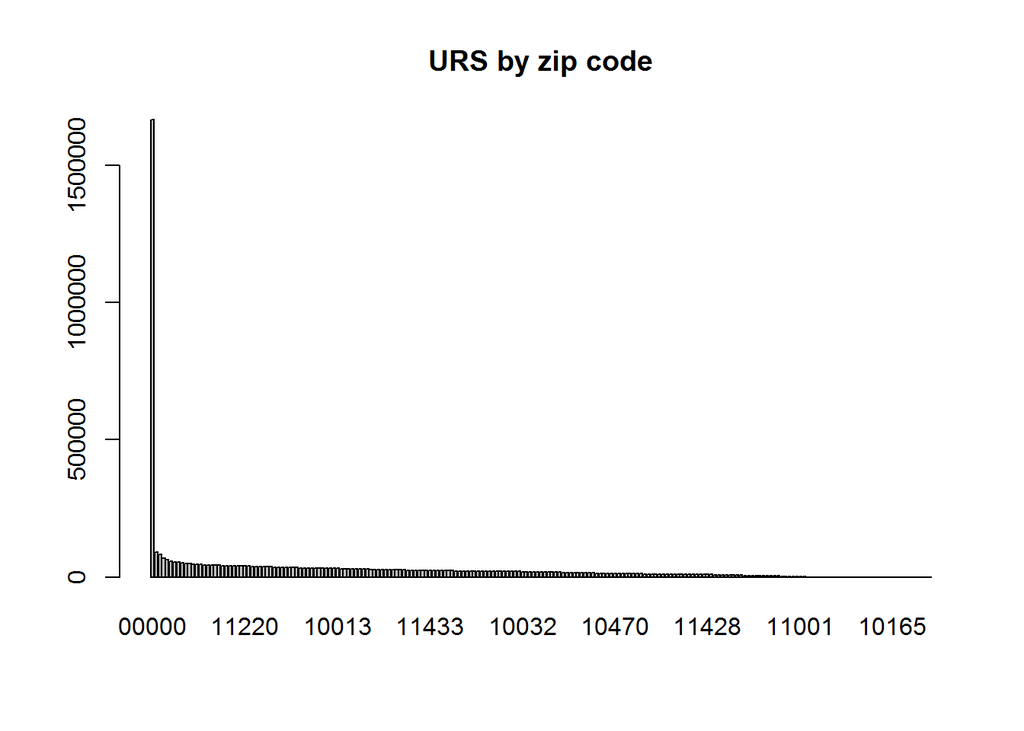

```r
# JB - - Is there any way to exclude the 00000 ZIP code from these charts? it destroyes the entire scale :/

bp <- barplot(URS.Z.ord[,"x"], ylab="", xlab="", names.arg=as.character(URS.Z.ord[,"ZIP.CODE"]), main="URS by zip code")
```

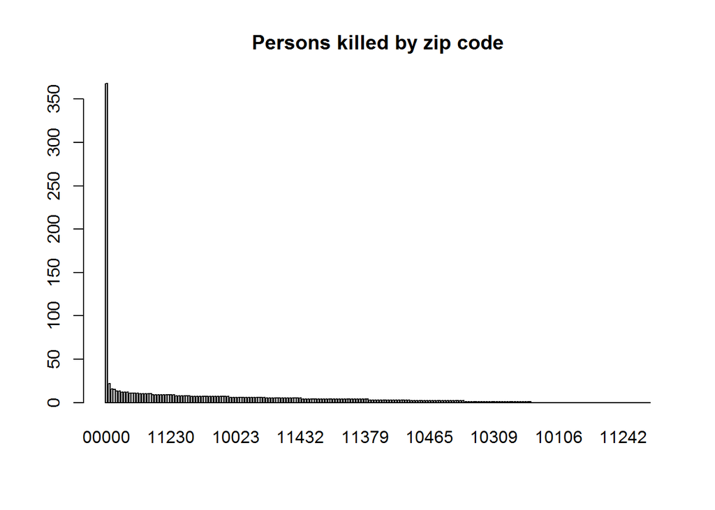

```r
bp <- barplot(PERSONS.K.Z.ord[,"x"], ylab="", xlab="",names.arg=as.character(PERSONS.K.Z.ord[,"ZIP.CODE"]), main="Persons killed by zip code")
```

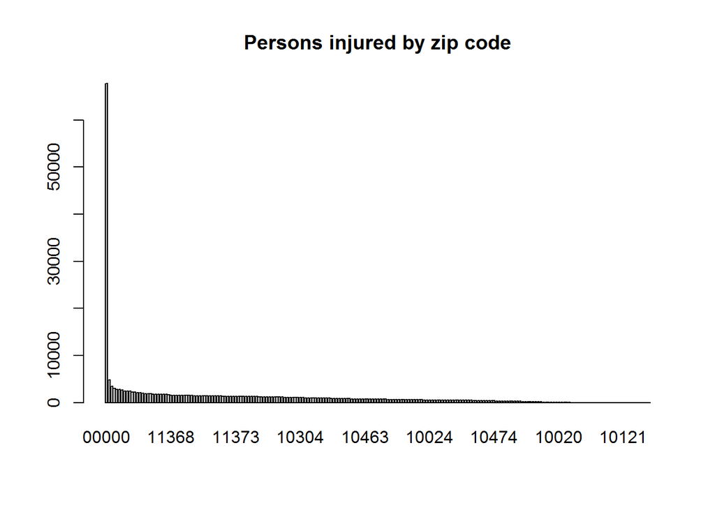

```r
#pareto.chart(PERSONS.K.Z_nb)

bp <- barplot(PERSONS.I.Z.ord[,"x"], ylab="", xlab="",names.arg=as.character(PERSONS.I.Z.ord[,"ZIP.CODE"]), main="Persons injured by zip code")
```